# Prosper Loan Data

## Preliminary Wrangling

> - This data set contains 113,937 loans with 81 variables on each loan, including loan amount, borrower rate (or interest rate), current loan status, borrower income, and many others supplied by a credit company called Propser. Prosper or Prosper Marketplace Inc. is a San Francisco, California based company specializing in loans at low interest rates to the borrowers.
> - This [data dictionary](https://docs.google.com/spreadsheets/d/1gDyi_L4UvIrLTEC6Wri5nbaMmkGmLQBk-Yx3z0XDEtI/edit#gid=0) explains the variables in the data set.

```python
# import all packages and set plots to be embedded inline
import numpy as np
import pandas as pd
import matplotlib.pyplot as plt
import seaborn as sb

%matplotlib inline
```

We will start by loading in the dataset and wrangling the data

```python
#loading in the data into a pandas dataframe and viewing the first 5 rows
df = pd.read_csv("prosperLoanData.csv")
df.head()
```

|  | ListingKey | ListingNumber | ListingCreationDate | CreditGrade | Term | LoanStatus | ClosedDate | BorrowerAPR | BorrowerRate | LenderYield | ... | LP_ServiceFees | LP_CollectionFees | LP_GrossPrincipalLoss | LP_NetPrincipalLoss | LP_NonPrincipalRecoverypayments | PercentFunded | Recommendations | InvestmentFromFriendsCount | InvestmentFromFriendsAmount | Investors |
| --- | --- | --- | --- | --- | --- | --- | --- | --- | --- | --- | --- | --- | --- | --- | --- | --- | --- | --- | --- | --- | --- |
| 0 | 1021339766868145413AB3B | 193129 | 2007-08-26 19:09:29.263000000 | C | 36 | Completed | 2009-08-14 00:00:00 | 0.16516 | 0.1580 | 0.1380 | ... | -133.18 | 0.0 | 0.0 | 0.0 | 0.0 | 1.0 | 0 | 0 | 0.0 | 258 |
| 1 | 10273602499503308B223C1 | 1209647 | 2014-02-27 08:28:07.900000000 | NaN | 36 | Current | NaN | 0.12016 | 0.0920 | 0.0820 | ... | 0.00 | 0.0 | 0.0 | 0.0 | 0.0 | 1.0 | 0 | 0 | 0.0 | 1 |
| 2 | 0EE9337825851032864889A | 81716 | 2007-01-05 15:00:47.090000000 | HR | 36 | Completed | 2009-12-17 00:00:00 | 0.28269 | 0.2750 | 0.2400 | ... | -24.20 | 0.0 | 0.0 | 0.0 | 0.0 | 1.0 | 0 | 0 | 0.0 | 41 |
| 3 | 0EF5356002482715299901A | 658116 | 2012-10-22 11:02:35.010000000 | NaN | 36 | Current | NaN | 0.12528 | 0.0974 | 0.0874 | ... | -108.01 | 0.0 | 0.0 | 0.0 | 0.0 | 1.0 | 0 | 0 | 0.0 | 158 |
| 4 | 0F023589499656230C5E3E2 | 909464 | 2013-09-14 18:38:39.097000000 | NaN | 36 | Current | NaN | 0.24614 | 0.2085 | 0.1985 | ... | -60.27 | 0.0 | 0.0 | 0.0 | 0.0 | 1.0 | 0 | 0 | 0.0 | 20 |

5 rows × 81 columns

```python
# Displaying the dimensions of the dataframe
df.shape
```

```
(113937, 81)
```

```python
# Using the infos method to display the data type for each column
df.info()
```

```
<class 'pandas.core.frame.DataFrame'>
RangeIndex: 113937 entries, 0 to 113936
Data columns (total 81 columns):
 #   Column                               Non-Null Count   Dtype
---  ------                               --------------   -----
 0   ListingKey                           113937 non-null  object
 1   ListingNumber                        113937 non-null  int64
 2   ListingCreationDate                  113937 non-null  object
 3   CreditGrade                          28953 non-null   object
 4   Term                                 113937 non-null  int64
 5   LoanStatus                           113937 non-null  object
 6   ClosedDate                           55089 non-null   object
 7   BorrowerAPR                          113912 non-null  float64
 8   BorrowerRate                         113937 non-null  float64
 9   LenderYield                          113937 non-null  float64
```

[output cut: 73 more lines]

```python
# check if there is a duplicated row in the dataset
df.duplicated().any()
```

```
False
```

**Seems that the data set is free of any duplicates thus we will proceed with the next step which is dropping the columns we are not intrested in for the purpose of this investigation.**

For the purporse of this investigation I will be considering the following variables:

> Term, LoanStatus, BorrowerRate, ProsperRating (Alpha), ProsperScore, ListingCategory (numeric), BorrowerState, EmploymentStatus, DelinquenciesLast7Years, StatedMonthlyIncome, LoanOriginalAmount, LoanOriginationDate

```python
# Filtring the dataset based on the variables mentioned above
# First we create a list with the variables we are intrested in
sub_set = ['Term', 'LoanStatus', 'BorrowerRate', 'ProsperRating (Alpha)', 'ProsperScore', 'ListingCategory (numeric)',
           'BorrowerState', 'EmploymentStatus', 'DelinquenciesLast7Years', 'StatedMonthlyIncome',
           'LoanOriginalAmount', 'LoanOriginationDate']

# Then we filter the dataframe using the dataframe method to create a new dataframe with only the variables of intrest
df_sub = df[sub_set]
```

```python
# Viewing the first 5 rows of the filtered dataset
df_sub.head()
```

|  | Term | LoanStatus | BorrowerRate | ProsperRating (Alpha) | ProsperScore | ListingCategory (numeric) | BorrowerState | EmploymentStatus | DelinquenciesLast7Years | StatedMonthlyIncome | LoanOriginalAmount | LoanOriginationDate |
| --- | --- | --- | --- | --- | --- | --- | --- | --- | --- | --- | --- | --- |
| 0 | 36 | Completed | 0.1580 | NaN | NaN | 0 | CO | Self-employed | 4.0 | 3083.333333 | 9425 | 2007-09-12 00:00:00 |
| 1 | 36 | Current | 0.0920 | A | 7.0 | 2 | CO | Employed | 0.0 | 6125.000000 | 10000 | 2014-03-03 00:00:00 |
| 2 | 36 | Completed | 0.2750 | NaN | NaN | 0 | GA | Not available | 0.0 | 2083.333333 | 3001 | 2007-01-17 00:00:00 |
| 3 | 36 | Current | 0.0974 | A | 9.0 | 16 | GA | Employed | 14.0 | 2875.000000 | 10000 | 2012-11-01 00:00:00 |
| 4 | 36 | Current | 0.2085 | D | 4.0 | 2 | MN | Employed | 0.0 | 9583.333333 | 15000 | 2013-09-20 00:00:00 |

**It seems that our dataset contains some missing values, thus the next step is deciding what to do with the missing values**

```python
# Checking for null values
df_sub.isna().sum()
```

```
Term                             0
LoanStatus                       0
BorrowerRate                     0
ProsperRating (Alpha)        29084
ProsperScore                 29084
ListingCategory (numeric)        0
BorrowerState                 5515
EmploymentStatus              2255
DelinquenciesLast7Years        990
StatedMonthlyIncome              0
LoanOriginalAmount               0
LoanOriginationDate              0
dtype: int64
```

**Proser only started using the prosper Rating/Score in 2009 thus we have a number of missing values, I have decided to drop these rows**

```python
# Dropping the null values and checking if we have any remaining null values
df_sub = df_sub.dropna(subset = ['ProsperRating (Alpha)'])
df_sub.isna().sum()
```

```
Term                         0
LoanStatus                   0
BorrowerRate                 0
ProsperRating (Alpha)        0
ProsperScore                 0
ListingCategory (numeric)    0
BorrowerState                0
EmploymentStatus             0
DelinquenciesLast7Years      0
StatedMonthlyIncome          0
LoanOriginalAmount           0
LoanOriginationDate          0
dtype: int64
```

**Seems that by dropping the null values in "ProsperRating (Alpha)" we have effectivly removed all the null values from our filted dataset**

It seems that the "LoanOriginationDate" column is in Object type and we need to conver that to datetime datatype

```python
# Converting the datatype of 'LoanOriginationDate' to datetime using pandas
df_sub['LoanOriginationDate'] = pd.to_datetime(df_sub['LoanOriginationDate'])
```

```python
# Displaying the dimensions of the filtered dataframe
df_sub.shape
```

```
(84853, 12)
```

```python
# Using the infos method to display the data type for each column for the filtered dataframe
df_sub.info()
```

```
<class 'pandas.core.frame.DataFrame'>
Int64Index: 84853 entries, 1 to 113936
Data columns (total 12 columns):
 #   Column                     Non-Null Count  Dtype
---  ------                     --------------  -----
 0   Term                       84853 non-null  int64
 1   LoanStatus                 84853 non-null  object
 2   BorrowerRate               84853 non-null  float64
 3   ProsperRating (Alpha)      84853 non-null  object
 4   ProsperScore               84853 non-null  float64
 5   ListingCategory (numeric)  84853 non-null  int64
 6   BorrowerState              84853 non-null  object
 7   EmploymentStatus           84853 non-null  object
 8   DelinquenciesLast7Years    84853 non-null  float64
 9   StatedMonthlyIncome        84853 non-null  float64
 10  LoanOriginalAmount         84853 non-null  int64
 11  LoanOriginationDate        84853 non-null  datetime64[ns]
dtypes: datetime64[ns](1), float64(4), int64(3), object(4)
memory usage: 8.4+ MB
```

## Descriptive Statistics

### The final step before starting the Exploration process is the use Descriptive statistics to show a summary of the data.

Since we have a mix of numerical and categorical features we need to show a summry for each type.

### For Numerical Variables

```python
# Using the describe method to show a table with the summary statistics for numeric values
# Using the drop method to drop the count which we alreay know to be 84853
df_sub.describe().drop("count", axis = 0)
```

|  | Term | BorrowerRate | ProsperScore | ListingCategory (numeric) | DelinquenciesLast7Years | StatedMonthlyIncome | LoanOriginalAmount |
| --- | --- | --- | --- | --- | --- | --- | --- |
| mean | 42.486135 | 0.196022 | 5.950067 | 3.312647 | 3.659435 | 5.931175e+03 | 9083.440515 |
| std | 11.640346 | 0.074631 | 2.376501 | 4.364277 | 9.347957 | 8.239944e+03 | 6287.860058 |
| min | 12.000000 | 0.040000 | 1.000000 | 0.000000 | 0.000000 | 0.000000e+00 | 1000.000000 |
| 25% | 36.000000 | 0.135900 | 4.000000 | 1.000000 | 0.000000 | 3.434000e+03 | 4000.000000 |
| 50% | 36.000000 | 0.187500 | 6.000000 | 1.000000 | 0.000000 | 5.000000e+03 | 7500.000000 |
| 75% | 60.000000 | 0.257400 | 8.000000 | 3.000000 | 2.000000 | 7.083333e+03 | 13500.000000 |
| max | 60.000000 | 0.360000 | 11.000000 | 20.000000 | 99.000000 | 1.750003e+06 | 35000.000000 |

### For categorical Variables

```python
# Using the describe method to show a table with the summary statistics for categorical values by using the
# "include = [np.object]" argument
# Using the drop method to drop the count which we alreay know to be 84853
df_sub.describe(include = [np.object]).drop("count", axis = 0)
```

|  | LoanStatus | ProsperRating (Alpha) | BorrowerState | EmploymentStatus |
| --- | --- | --- | --- | --- |
| unique | 11 | 7 | 48 | 7 |
| top | Current | C | CA | Employed |
| freq | 56576 | 18345 | 10761 | 67310 |

### What is the structure of your dataset?

> The orinigal dataset containted 113937 rows of data, and after filtering the dataset and performing initial wrangling, the resulting dataset contains 84853 rows of data for the following variables:  
> Term, LoanStatus, BorrowerRate, ProsperRating (Alpha), ProsperScore, ListingCategory (numeric), BorrowerState, EmploymentStatus, DelinquenciesLast7Years, StatedMonthlyIncome, LoanOriginalAmount, LoanOriginationDate  
> Most of the variables we are intrested in are in numeric format with the exception of the following:  
> LoanStatus, ProsperRating (Alpha), BorrowerState, EmploymentStatus and LoanOriginationDate

### What is/are the main feature(s) of interest in your dataset?

> The main features of intrest in this datset is the Loan Status and what is the effect of the chosen variables on the status of the loan.

### What features in the dataset do you think will help support your investigation into your feature(s) of interest?

> After an initial investigation of the data set via the data dictionary, I have came to the conclusion that the PropserRating/Score with the EmployementStatus, LoanOriginalAmount and DelinquinciesLast7Years are the most important factors in determining what is likely to happen with the Loan Status

## Univariate Exploration

> In this section, I will be investigating the distributions of individual variables.

```python
# Setting the default color palette
base_color = sb.color_palette()[0]
```

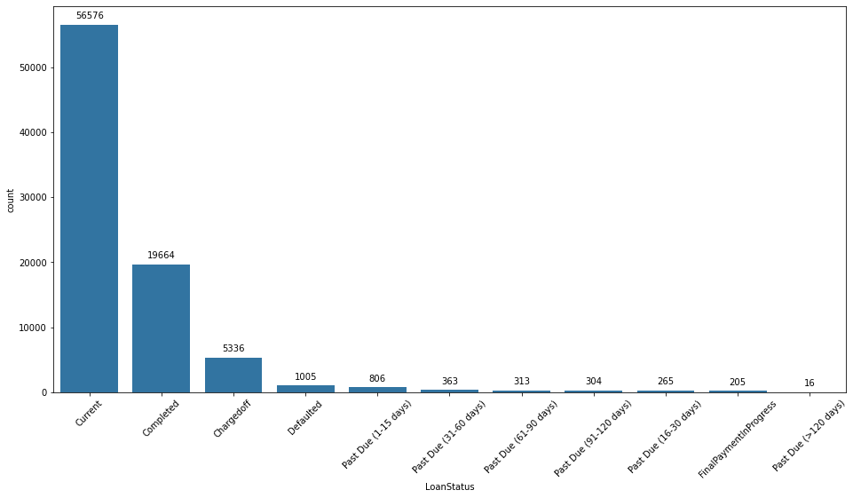

```python
# We will start by checking the main variable in question, the "LoanStatus"
# By using the value_counts method to soirt the values in descending order of count we can then use the index method to return
# A series with the descending order of the LoanStatus and order the Bar Chart using that
# Finally by using a for loop we can have the count of the values appear as text on top of the each bar

freq_status = df_sub['LoanStatus'].value_counts()
status_order = freq_status.index
plt.figure(figsize=[16, 8])
plt.xticks(rotation=45)
sb.countplot(data = df_sub, x = 'LoanStatus', color = base_color, order = status_order);
for i in range (freq_status.shape[0]):
    count = freq_status[i]
    plt.text(i, count+2000, count, ha = 'center', va='top')
```

**It seems that most of the loans in this dataset are current, followed completed, followed by chargedoff, followed by an insiginat number of Defaulted loans, the the remaining LoanStatus values being occuring less than a 1000 times.**

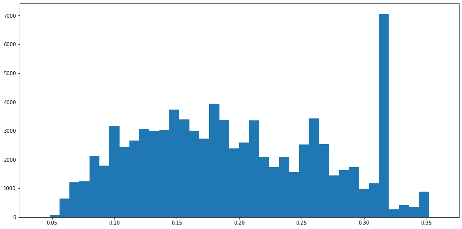

```python
# Next I will be exploring the "BorrowerRate" Variable

plt.figure(figsize=[16, 8])
plt.hist(data = df_sub, x = 'BorrowerRate', bins = 40, color = base_color);
```

**I have chosen to use 40 bins since using any lower will skew the values to show a significant peak at around 0.15, the result seem to indicate that our the distrubtion of BorrowerRate is bimodal with 2 peaks at 0.32 and 0.18, the most commong value for the BorrowerRate seems to be around 0.32**

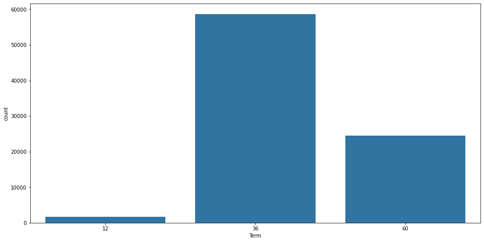

```python
# Next I will be exploring the "term" variable

plt.figure(figsize=[16, 8])
sb.countplot(data = df_sub, x = 'Term', color = base_color);
```

**The results here indicate that the most common term in the dataset is the 36 month term with 60 month following after and 12 month being the least common loan duration**

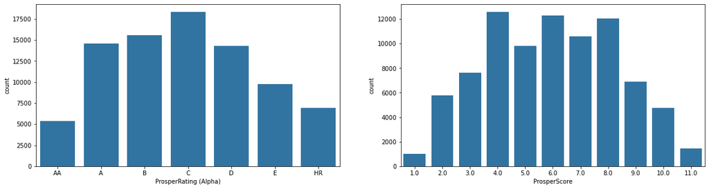

```python
# Next I will be exploring the "ProsperRating (Alpha)" and "ProsperScore" variables and since they're similar
# I will exploring them on 2 graphs next to each other
# First we convert the datatype of "ProsperRating (Alpha)" to catergorical data using Pandas

rating_ordered = ['AA', 'A', 'B', 'C', 'D', 'E', 'HR']
ordered_rating = pd.api.types.CategoricalDtype(ordered = True, categories = rating_ordered)
df_sub['ProsperRating (Alpha)'] = df_sub['ProsperRating (Alpha)'].astype(ordered_rating)

plt.figure(figsize = [20, 5])
plt.subplot(1, 2, 1)
sb.countplot(data = df_sub, x= 'ProsperRating (Alpha)', color = base_color);
plt.subplot(1, 2, 2)
sb.countplot(data = df_sub, x= 'ProsperScore', color = base_color);
```

**As expected the ProsperRating and ProsperScore variables are very similar since they basically represent the risk score, the data is also normally distrubted with the C ProsperRating and 4 ProsperScore being the most common, and AA and HR ProsperRating and 1 and 11 ProsperScore being the least commong**

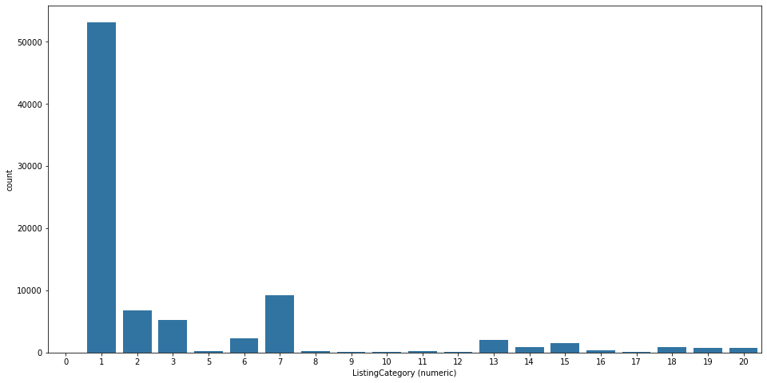

```python
# Next I will be exploring the "ListingCategory (numeric)" variable

plt.figure(figsize = [16, 8])
sb.countplot(data = df_sub, x='ListingCategory (numeric)', color = base_color);
```

> The category of the listing that the borrower selected when posting their listing: 0 - Not Available, 1 - Debt Consolidation, 2 - Home Improvement, 3 - Business, 4 - Personal Loan, 5 - Student Use, 6 - Auto, 7- Other, 8 - Baby&Adoption, 9 - Boat, 10 - Cosmetic Procedure, 11 - Engagement Ring, 12 - Green Loans, 13 - Household Expenses, 14 - Large Purchases, 15 - Medical/Dental, 16 - Motorcycle, 17 - RV, 18 - Taxes, 19 - Vacation, 20 - Wedding Loans

**From this graph is seems that that the most common reason for taking out a loan via prosper is "Debt Consolidation", followed by "Other", then by "Home Improvement" and "Business"**

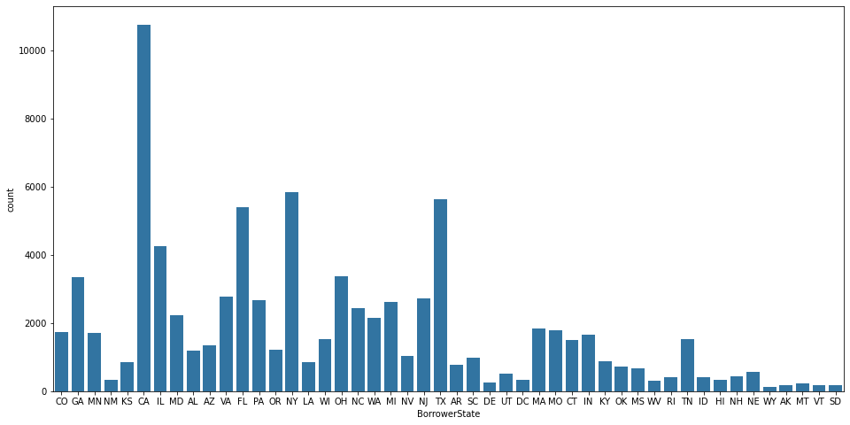

```python
# Next I will be exploring the "BorrowerState" variable

plt.figure(figsize = [16, 8])
sb.countplot(data = df_sub, x = 'BorrowerState', color = base_color);
```

**It seems that proper give out the most number of loans to people in California, followed by New York, Texas and Florida**

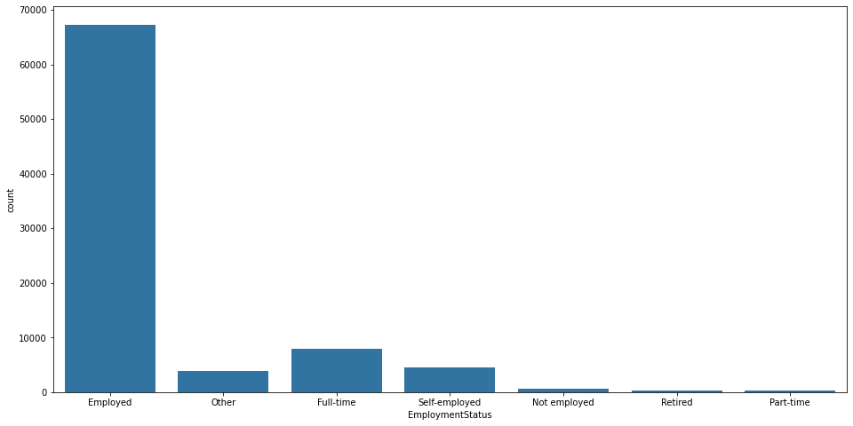

```python
# Next I will be exploring the "EmploymentStatus" variable

plt.figure(figsize = [16, 8])
sb.countplot(data = df_sub, x = 'EmploymentStatus', color = base_color);
```

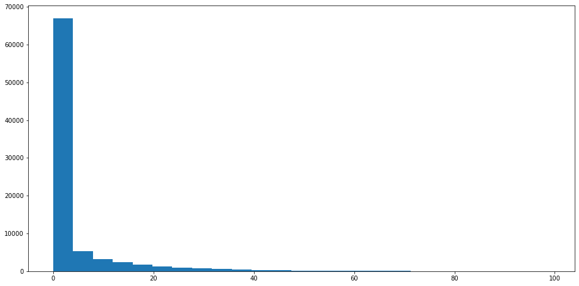

```python
# Next I will be exploring the "DelinquenciesLast7Years" variable

plt.figure(figsize = [16, 8])
plt.hist(data = df_sub, x = 'DelinquenciesLast7Years', bins = 25, color = base_color);
```

**Here I have chosen to use 25 bins since the majority of Number of Delinquencies is at 0 with a small number of borrowers having delinquencies larger than 20, it seems that the majority of DelinquenciesLast7Years are confined within the 0-20 range, being extremly skewed to the right**

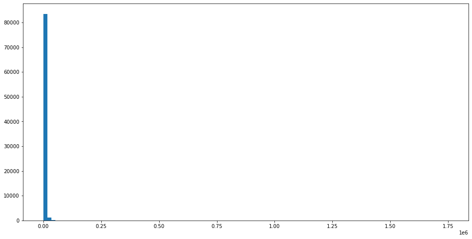

```python
# Next I will be exploring the "StatedMonthlyIncome" variable

plt.figure(figsize = [16, 8])
plt.hist(data = df_sub, x = 'StatedMonthlyIncome', bins = 100, color = base_color);
```

**It seems that the data is right skewed with outliers forcing our view to be inaccurate, thus we need to limit our view, I have chosen to use the three-sigma rule of thumb which states that most of the data should lie within 3 standard deviations of the mean**

```python
# First we need to calculate the mean and standard deviations of the "StatedMonthlyIncome" variable

income_mean = df_sub.StatedMonthlyIncome.mean()
income_std = df_sub.StatedMonthlyIncome.std()

# Since we're limiting our view 3 standard deviations of the mean, we are going to calculate it using by the following

income_max = income_mean + 3*income_std
```

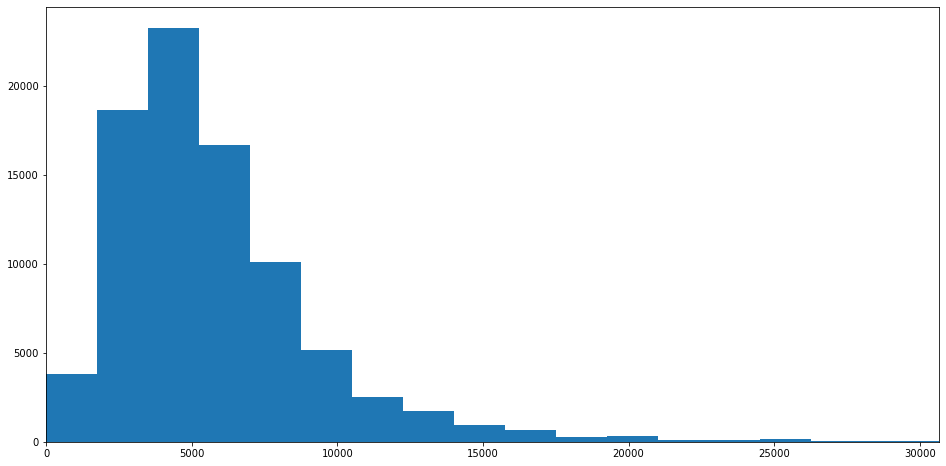

```python
# Finally we are going to draw the graph using the view calculated before

plt.figure(figsize = [16, 8])
plt.hist(data = df_sub, x = 'StatedMonthlyIncome', bins = 1000, color = base_color);
plt.xlim(0, income_max);
```

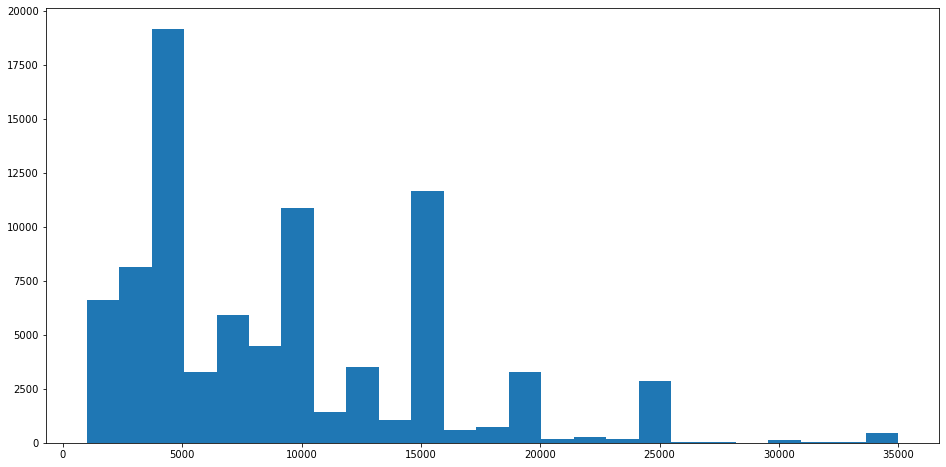

```python
# Next I will be exploring the "LoanOriginalAmount" variable

plt.figure(figsize = [16, 8])
plt.hist(data = df_sub, x='LoanOriginalAmount', bins = 25, color = base_color);
```

**It seems that the majority of the loans are around the 5000 range, with spikes every 5000, meaning that the borrowers tend to borrow money in increments of 5000**

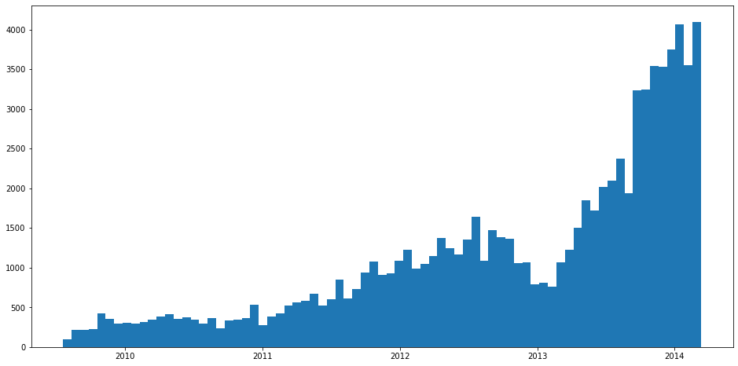

```python
# Finally I will be exploring the "LoanOriginationDate" variable

plt.figure(figsize = [16, 8])
plt.hist(data = df_sub, x='LoanOriginationDate', bins = 75, color = base_color);
```

**We only have data from 2009 to 2014 (5 years) for this variable and it seems that the number of loans are trending upwards with 2013 marking the start of considerable increase in the number of loans**

```python
# Here I will be performing further wrangling steps in order to move to Bivariate Exploration
# First I will remove the datapoints with outliers in the StatedMonthlyIncome variable

df_sub2 = df_sub[df_sub['StatedMonthlyIncome'] < income_max]
```

```python
# Next we will be considering the LoanStatus Variable
df_sub2.LoanStatus.value_counts()
```

```
Current                   56402
Completed                 19607
Chargedoff                 5326
Defaulted                  1005
Past Due (1-15 days)        804
Past Due (31-60 days)       363
Past Due (61-90 days)       312
Past Due (91-120 days)      304
Past Due (16-30 days)       265
FinalPaymentInProgress      204
Past Due (>120 days)         16
Name: LoanStatus, dtype: int64
```

```python
# I will be ignoring the current loans, loans where the final payment is in progress and
# any loans with Past Due of less than 120 days
# since the data is incomplete (we don't know if the loan is going to be defaulted on or completed)

df_sub2 = df_sub2[(df_sub2['LoanStatus'] == 'Completed') | (df_sub2['LoanStatus'] == 'Chargedoff')
                  | (df_sub2['LoanStatus'] == 'Defaulted')]
```

```python
# Finally we will check the dimensions of our new dataset

df_sub2.shape
```

```
(25938, 12)
```

**This wrangling process dropped our dataset down to 25938 rows of data from 84853 that we had via our initial wrangling process**

### Discuss the distribution(s) of your variable(s) of interest. Were there any unusual points? Did you need to perform any transformations?

> The most intresting variable here would be the loan status, it seems that most of the loans are currents with a very small number of defaulted loans. The next intresting variable here would be the ProsperRating and the ProsperScore valiable and those seem to be normally distrubted which is to be expected. The existence of extreme outliers in the StatedMonthlyIncome seems to indicate that there are erroneous datapoints in the dataset no transformation will be needed here since it's a data error and is to be removed. Intrestgly the most common state where customer took out loans happens to be CA, NY, TX and FL where CA and NY can be explained by the fact that they are the 2nd and 3rd most expensive states in terms of living expenses in the US.

### Of the features you investigated, were there any unusual distributions? Did you perform any operations on the data to tidy, adjust, or change the form of the data? If so, why did you do this?

> The only usual distrubtion came about from the StatedMonthlyIncome variable and that was resovled by removing the erroneous datapoints, the second step done to clean the data for further investigation is to only consider loans that are not current, since we don't know the results of the loan (whether it will default or complete)

## Bivariate Exploration

> In this section, we will investigate the relationships between pairs of variables in our data.

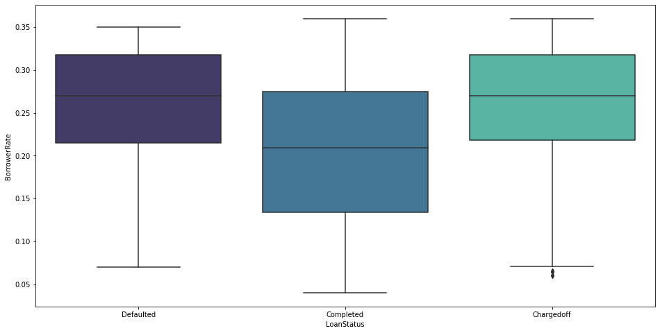

```python
# First off I'm going to start by exploring the relationship between the BorrowerRate and the LoanStatus

plt.figure(figsize = [16, 8])
sb.boxplot(data = df_sub2, x = 'LoanStatus', y = 'BorrowerRate', palette = 'mako');
```

**It seems that Defaulted and Chargedoff loans tend to have a higher BorrowerRate than Completed loans, this is likely due to the fact that high risk loans have a higher rate than low risk loans**

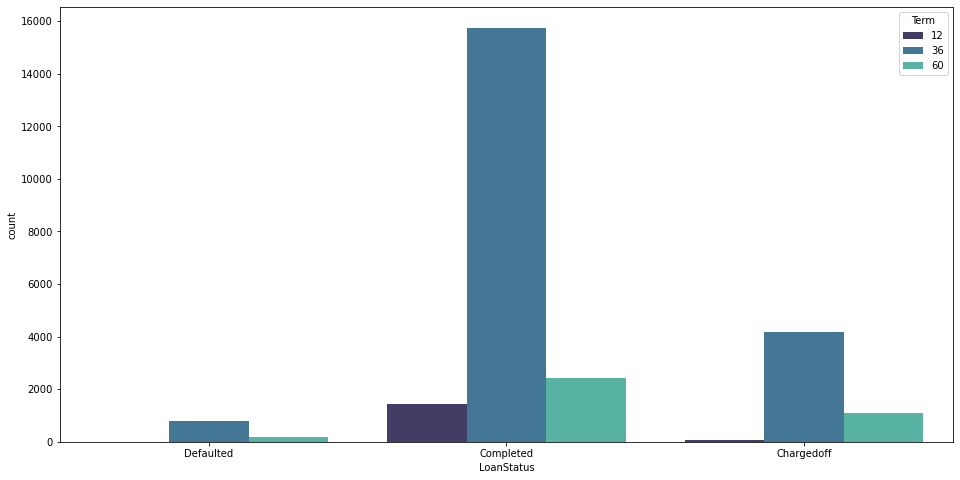

```python
# Next I'm going to explore the relationship between Term and LoanStatus

plt.figure(figsize = [16, 8])
sb.countplot(data = df_sub2 , x = 'LoanStatus', hue = 'Term', palette = 'mako');
```

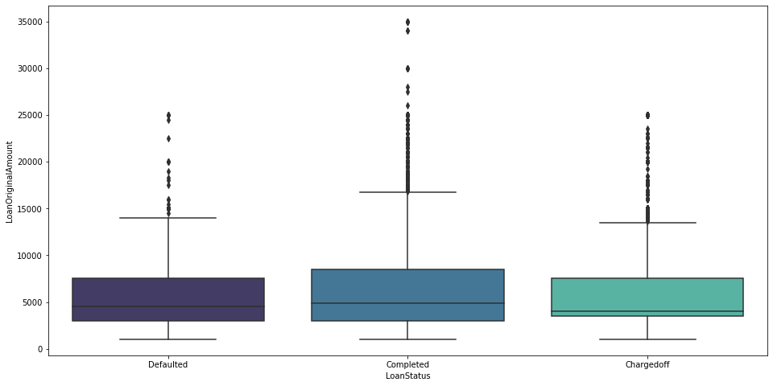

```python
# Next I'm going to explore the relationship between LoanOriginalAmount and LoanStatus

plt.figure(figsize = [16, 8])
sb.boxplot(data = df_sub2 , x = 'LoanStatus', y = 'LoanOriginalAmount', palette = 'mako');
```

**It seems that Defaulted and Chargedoff loans tend to have a slightly lower LoanOriginalAmount than Completed loans, this is likely comes from the fact that lenders tend to provide a lower loan amount to higher risk lenders since they are more likely to default on loans**

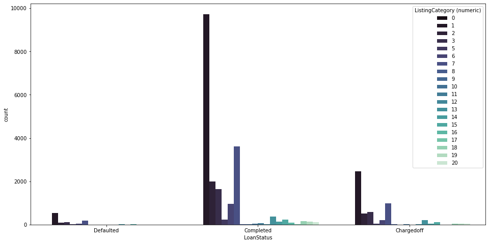

```python
# Next I'm going to explore the relationship between LoanOriginalAmount and LoanStatus

plt.figure(figsize = [16, 8])
sb.countplot(data = df_sub2 , x = 'LoanStatus', hue = 'ListingCategory (numeric)', palette = 'mako');
```

```python
# The previous graph does not constitute a good view of the data since most of the it is in
# "Debt Consolidation", "Other", "Home Improvement" and "Business"
# Thus a futher data wrangling step is required here, where we remove the other Categories

df_sub3 = df_sub2[(df_sub2['ListingCategory (numeric)'] == 1 ) | (df_sub2['ListingCategory (numeric)'] == 3 ) |
                  (df_sub2['ListingCategory (numeric)'] == 2 ) | (df_sub2['ListingCategory (numeric)'] == 7 )]
# Dictionary with the categories we are intrested in showing
cat_dict = {1: 'Debt Consolidation', 2: 'Home Improvement', 3: 'Business', 7: 'Other'}
df_sub3['ListingCategory'] = df_sub3['ListingCategory (numeric)'].map(cat_dict)
```

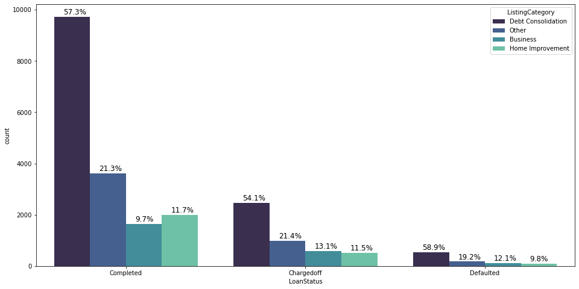

```python
# Ploting the graph again using the filtered data and creating a function to write the proportion percentage on top of each bar

def print_proportion(plot, x, y):
    """Function to write the proportion percentage on top of each bar on the countplot graphs,
    x values needs to be in decending order for the function to work correctly,
    plot is the name of the graph variable,
    x is the variable that we are categorizing for in the x axis,
    y is the variable that we are categorizing for in the y axis (count)"""
    # using the patches method to split each bar, then using get_height() to get the height of each bar
    a = [p.get_height() for p in plot.patches]
    patch = [p for p in plot.patches] # Split each bar into it's own "patch"
    for i in range(x.nunique()): # loops for the number of values in the x axis
        total = x.value_counts().values[i] # Finds the total for all each x value
        for j in range(y.nunique()): # loops for the number of values in the y axis
            # Find the proportion for each bar up to 1 decimalplace
            proportion = '{:.1f}%'.format(100 * a[(j*x.nunique() + i)]/total)
            # The X position formula for each proportion percentage
            x_pos = patch[(j*x.nunique() + i)].get_x() + patch[(j*x.nunique() + i)].get_width()/ 2 - 0.05
            # The Y position formula for each proportion percentage
            y_pos = patch[(j*x.nunique() + i)].get_y() + patch[(j*x.nunique() + i)].get_height()+ 100
            # Draw the text on top of each bar using the proportion x_pos and y_pos
            ax.annotate(proportion, (x_pos, y_pos), size = 12)

plt.figure(figsize = [16, 8])
ax = sb.countplot(data = df_sub3 , x = 'LoanStatus', hue = 'ListingCategory', palette = 'mako',
                  order = df_sub3['LoanStatus'].value_counts().index)
legend_labels, _= ax.get_legend_handles_labels()

print_proportion(ax, df_sub3['LoanStatus'], df_sub3['ListingCategory'])
```

**This graph shows that the proprtion for defaulting increases for Business (9.7% to 12.1%) and decreases for Home Improvement loans (11.7% to 9.8%) and for a similar result also occurs for the ChargedOff loans in which the proportaions increases for Business loans (9.7% to 13.1%) and decreases slightly for Home Improvement loans (11.7% to 11.5%)**

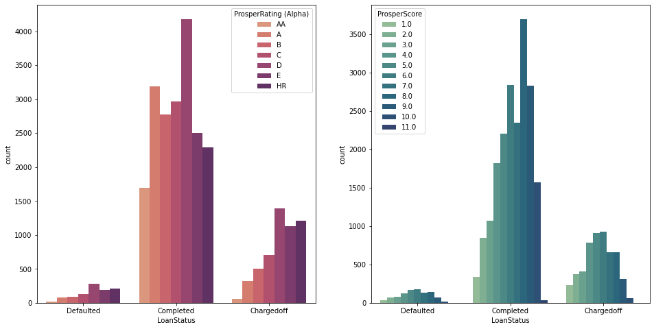

```python
# Next I'm going to explore the relationship between ProsperRating (Alpha) and Loan Status, and ProsperScore and Loan Status

plt.figure(figsize = [16, 8])
plt.subplot(1, 2, 1)
sb.countplot(data = df_sub2, x = 'LoanStatus', hue = 'ProsperRating (Alpha)', palette='flare');
plt.subplot(1, 2, 2)
sb.countplot(data = df_sub2, x = 'LoanStatus', hue = 'ProsperScore', palette='crest');
```

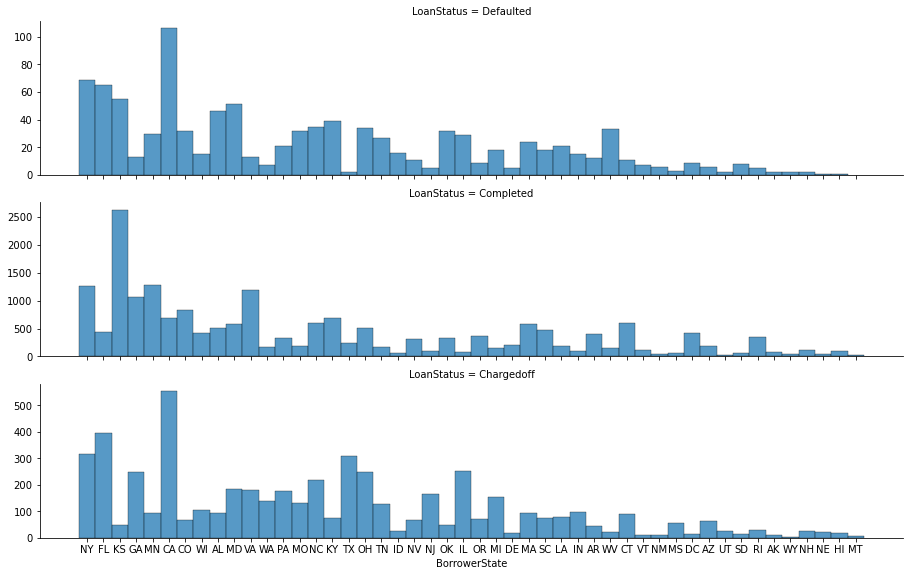

```python
# Next I will be going to explore the relationship between State and Loan Status
# Will also be creating a function to change the figsize

def mapsize(g, x, y):
    """Function to change the width, height for a plot where g is the plot, x is the width and y is the height"""
    g.fig.set_figwidth(x);
    g.fig.set_figheight(y);

g = sb.FacetGrid(data = df_sub2, col = 'LoanStatus', col_wrap = 1, sharey = False)
g.map(sb.histplot, "BorrowerState")
mapsize(g, 16, 8)
```

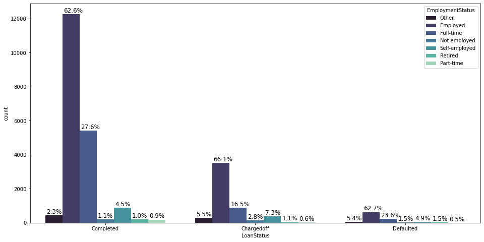

```python
# Next I will be exploring the relationship between EmploymentStatus and LoanStatus

plt.figure(figsize = [16, 8])
ax = sb.countplot(data = df_sub2 , x = 'LoanStatus', hue = 'EmploymentStatus', palette = 'mako',
                   order = df_sub2['LoanStatus'].value_counts().index);

print_proportion(ax, df_sub2['LoanStatus'], df_sub2['EmploymentStatus'])
```

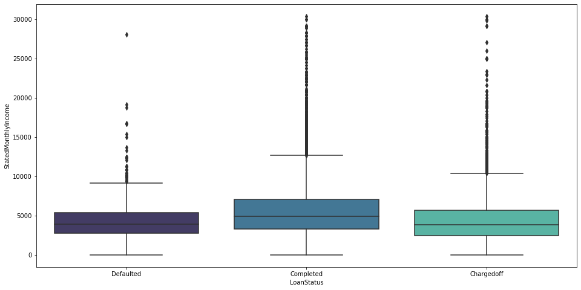

```python
# Next I will be exploring the relationship between StatedMonthlyIncome and the LoanStatus

plt.figure(figsize = [16, 8])
sb.boxplot(data = df_sub2 , x = 'LoanStatus', y = 'StatedMonthlyIncome', palette = 'mako');
```

**This plot shows that borrowers with completed loans tend to have a higher income on average than borrowers who default/Chargeoff on loans**

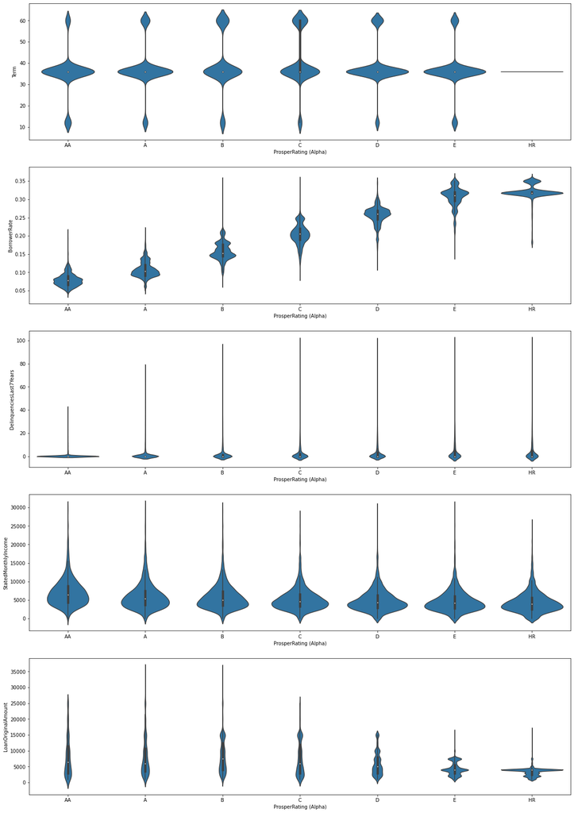

```python
# Finally I'm going to explore the relationship between ProsperRating (Alpha) and other variables of intrest

variables = ['Term', 'BorrowerRate', 'DelinquenciesLast7Years', 'StatedMonthlyIncome', 'LoanOriginalAmount']
plt.figure(figsize = [20, 30])
for i in range(len(variables)):
    plt.subplot(len(variables), 1, i+1)
    g = sb.violinplot(data = df_sub2, x = 'ProsperRating (Alpha)', y=variables[i], color=base_color)
```


## Multivariate Exploration

> Here I will be Creating plots of three or more variables to investigate the data even further.

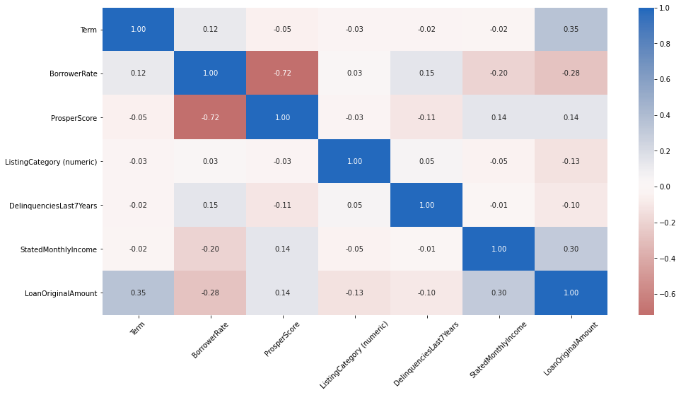

```python
# First off I will be starting by drawing a correlation matrix between all the variables

plt.figure(figsize = [16, 8])
sb.heatmap(df_sub2.corr(), annot = True, fmt = '.2f', cmap = 'vlag_r', center = 0)
plt.xticks(rotation=45);
```

**It seems that most of the variables are weakly correclated to each other with the exception of Term and LoanOriginalAmount, BorrowerRate and ProsperScore, BorrowerRate and LoanOriginalAmount and finally StatedMonthlyIncome and LoanOriginalAmount**

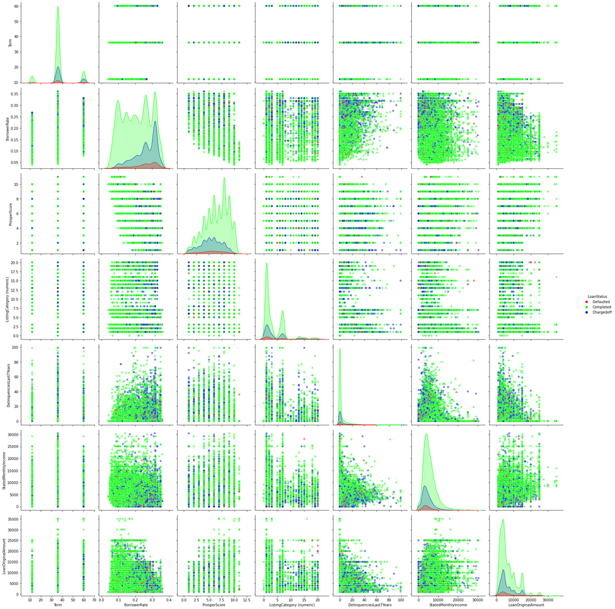

```python
# Next I will be using the pairplot function to show the relationship between different variables with respect to the LoanStatus

g = sb.pairplot(df_sub2, hue='LoanStatus',palette={'Defaulted': '#ff0000', 'Chargedoff': '#0000ff', 'Completed': '#00ff00'} ,plot_kws={'alpha': 0.5})
fig = g.fig;
mapsize(g, 25, 25)
```

**The plots shown above only serve to further confirm the results of the bivariate exploration done previously, with the best indication of future outcome of the loan being the ProsperRating/ProsperScore**

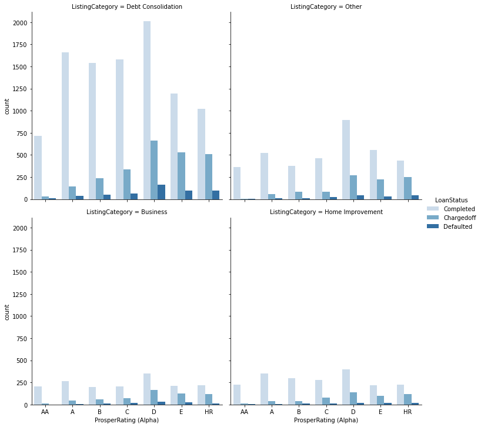

```python
# Next I will be comparing the ListingCategory and the Prosperrating in respect to the LoanStatus

plt.figure(figsize = [16, 8])
sb.catplot(data=df_sub3, x='ProsperRating (Alpha)', hue='LoanStatus', col='ListingCategory', kind='count', col_wrap=2,
           palette = 'Blues');
```

**This plot seems to confirm that previous finding as well in that Business loans tend to be slightly higher risk of being Defaulted/Chargedoff with no further information found here**

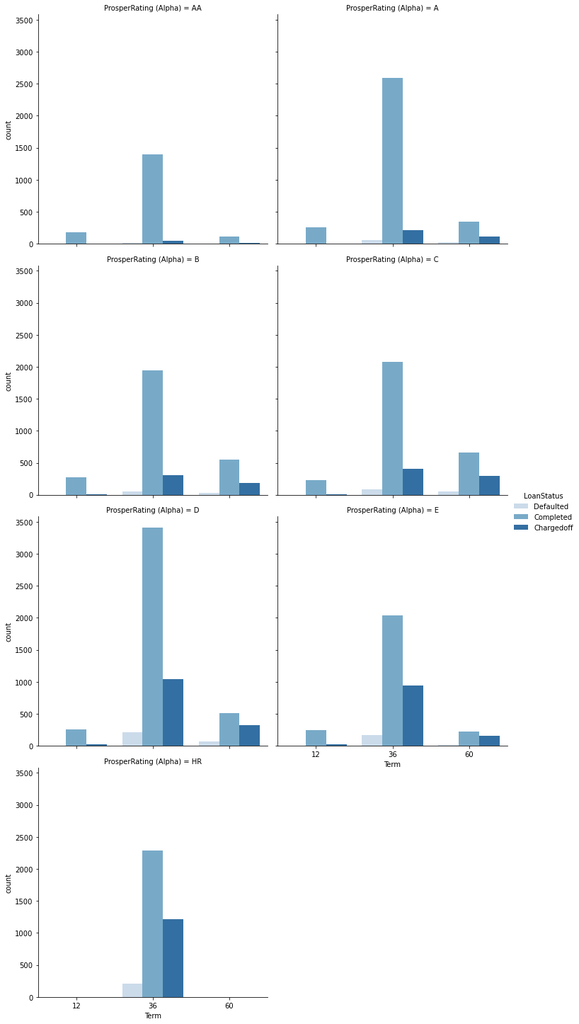

```python
# Finally I will be comparing the Term and the ProsperRating in respect to the LoanStatus

sb.catplot(data=df_sub2, x='Term', hue='LoanStatus', col='ProsperRating (Alpha)', kind='count', col_wrap=2,
           palette = 'Blues');
```

**Here we are shown again that the higher the term the more likely it is that the loan is defaulted on, however the plot shows that intrestingly high risk ratings have no 12 or 60 months term loans**

### Were there any interesting or surprising interactions between features?

> The fact that High Risk borrowers only had 36 term loans with no 12 or 60 months loans in the data set.